# Visualisation de données de réseau avec le Package R igraph

Vanesse Labeyrie & Sarah Ouadah

Mercredi matin 12 Juin 2019

Durée du TP : 1h

Pré-recquis : possession d’un objet igraph suite à la partie 2 de “Gestion de données”

## Plan :

1. Tester différents modes de représentation (graph layouts)
- Simple
- Basé sur la force
- Basé sur force et distance
- Basé sur la distance
2. Travailler l’esthétique et la lisibilité du graphe
- Label sur les noeuds
- Forme des noeuds
- Couleur des noeuds et arêtes
- Taille des noeuds - épaisseur des arêtes
3. Graphe bipartite

## Les packages

```r
library(igraph)
library(igraphdata)
```

# 1) Agencements de graphes (graph layouts)

- Rappel sur le réseau du club de karaté :

Zachary, W. W. (1977). An information flow model for conflict and fission in small groups. Journal of anthropological research, 33(4), 452-473.

Ce réseau a été observé pendant deux ans dans les années 70. Un noeud est un membre du club et une arête correspond à une interaction sociale entre deux membres. Suite à une dispute entre un enseignant et un membre de l’administration identifiés, il y a eu “séparation” en deux groupes. On a l’appartenance des membres aux deux camps ainsi que la fréquence relative d’interaction entre eux.

```r
data(karate)
karate
```

```
## IGRAPH 4b458a1 UNW- 34 78 -- Zachary's karate club network
## + attr: name (g/c), Citation (g/c), Author (g/c), Faction (v/n),
## | name (v/c), label (v/c), color (v/n), weight (e/n)
## + edges from 4b458a1 (vertex names):
##  [1] Mr Hi  --Actor 2  Mr Hi  --Actor 3  Mr Hi  --Actor 4
##  [4] Mr Hi  --Actor 5  Mr Hi  --Actor 6  Mr Hi  --Actor 7
##  [7] Mr Hi  --Actor 8  Mr Hi  --Actor 9  Mr Hi  --Actor 11
## [10] Mr Hi  --Actor 12 Mr Hi  --Actor 13 Mr Hi  --Actor 14
## [13] Mr Hi  --Actor 18 Mr Hi  --Actor 20 Mr Hi  --Actor 22
## [16] Mr Hi  --Actor 32 Actor 2--Actor 3  Actor 2--Actor 4
## [19] Actor 2--Actor 8  Actor 2--Actor 14 Actor 2--Actor 18
## + ... omitted several edges
```

## 1.2) Simple

On peut disposer les noeuds de manière circulaire.

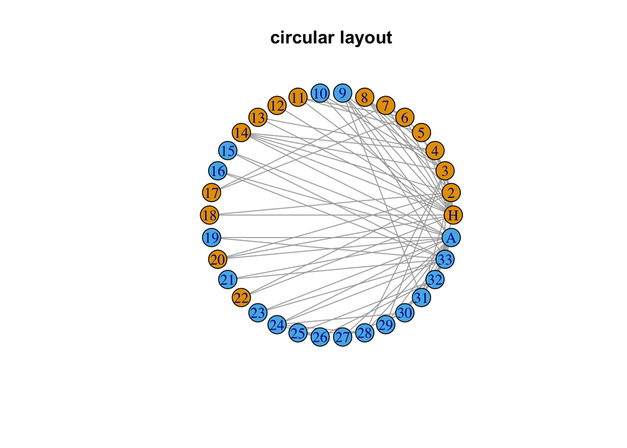

```r
plot(karate, layout=layout.circle)
title("circular layout")
```

Ce type de représentation n’est pas toujours très lisible et n’est pas le plus approprié pour rendre compte de la structure du réseau.

## 1.2) Basé sur la force

Parmi les algorithmes basés sur la force, un des plus populaires est celui de Fruchterman-Reingold. Les noeuds partageant le plus de liens - directs ou indirects - sont plus proches sur la représentation. Il est ainsi possible de visualiser les communautés. En revanche, l’algorithme n’est pas adapté aux réseaux de grande taille (> 1000 noeuds).

Remarque : il est possible de régler l’expansion du graphe.

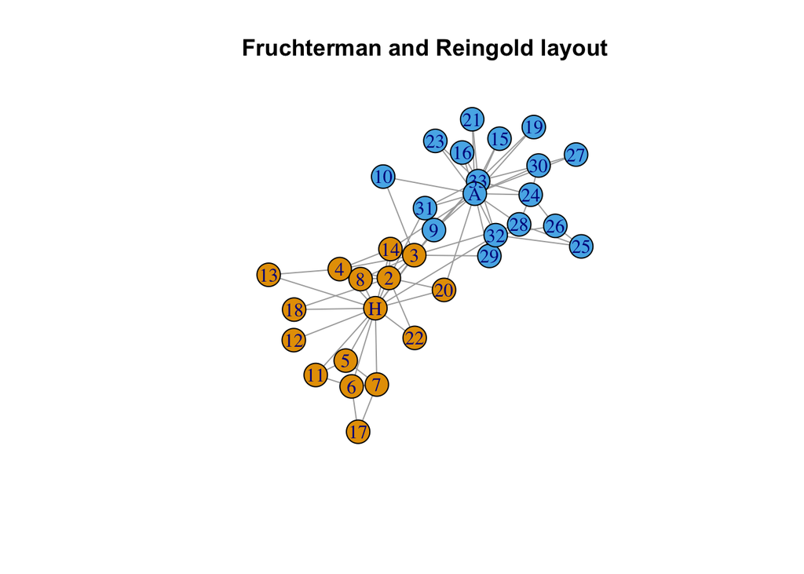

```r
plot(karate, layout=layout.fruchterman.reingold)
title("Fruchterman and Reingold layout")
```

Le graphe rend bien compte de l’existence de deux communautés: celle constituée autour de Mr Hi l’enseignant, et celle constituée autour de John A l’administratif. Ces deux individus sont situés au centre de chacune de leur communauté respective, tandis que les individus ayant peu de liens sont plutôt repoussés vers l’extérieur du graphe.

## 1.3) Basé sur force et distance

Le principe de l’algorithme de Kamada-Kawai est que la force qui attire les noeuds est proportionnelle à la distance entre eux. Cette méthode est adaptée pour les graphes ayant un nombre élévé de noeuds. En revanche, cet algorithme ne cherche pas à limiter le croisement des liens ni le chevauchement des noeuds.

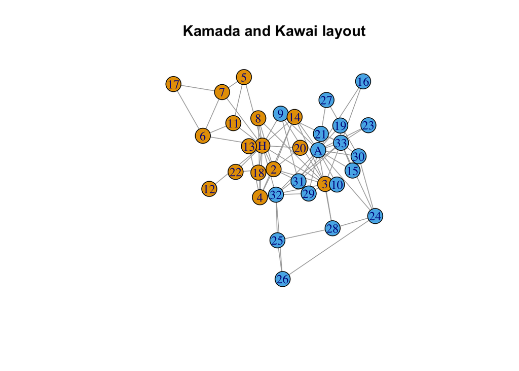

```r
plot(karate, layout=layout.kamada.kawai)
title("Kamada and Kawai layout")
```

Cette représentation fait bien ressortir les deux communautés également.

## 1.4) Basé sur la distance

Le MDS (Multi Dimensional Scaling) est un algorithme basé sur les distances entre noeuds du graphe (plus court chemin entre deux noeuds). L’avantage est que les distances ont une interprétation claire. En revanche, le graphe peut être peu lisible car les noeuds peuvent se superposer.

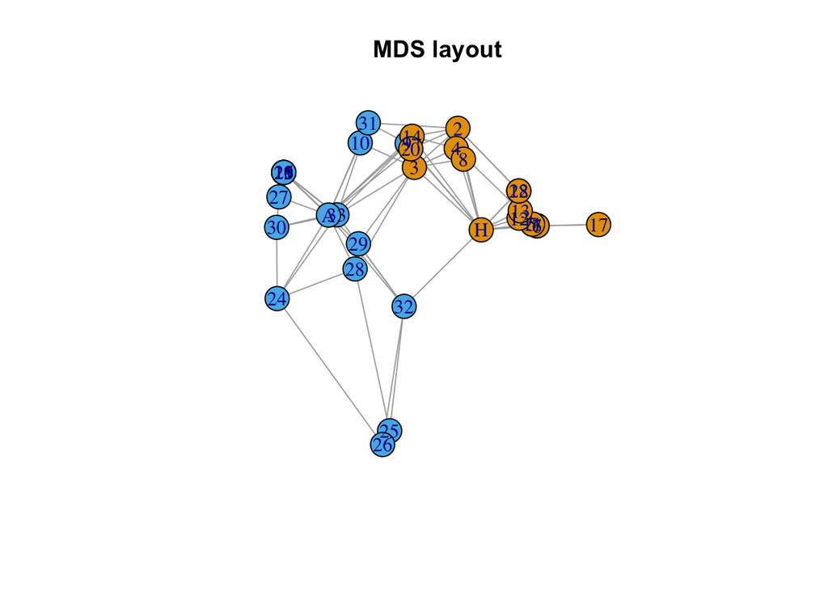

```r
l <- layout_with_mds(karate)
plot(karate, layout=l)
title("MDS layout")
```

La représentation est ici peu lisible.

# 2) Décorer un graphe selon les attributs sur les noeuds et les arêtes

- Choix du layout :

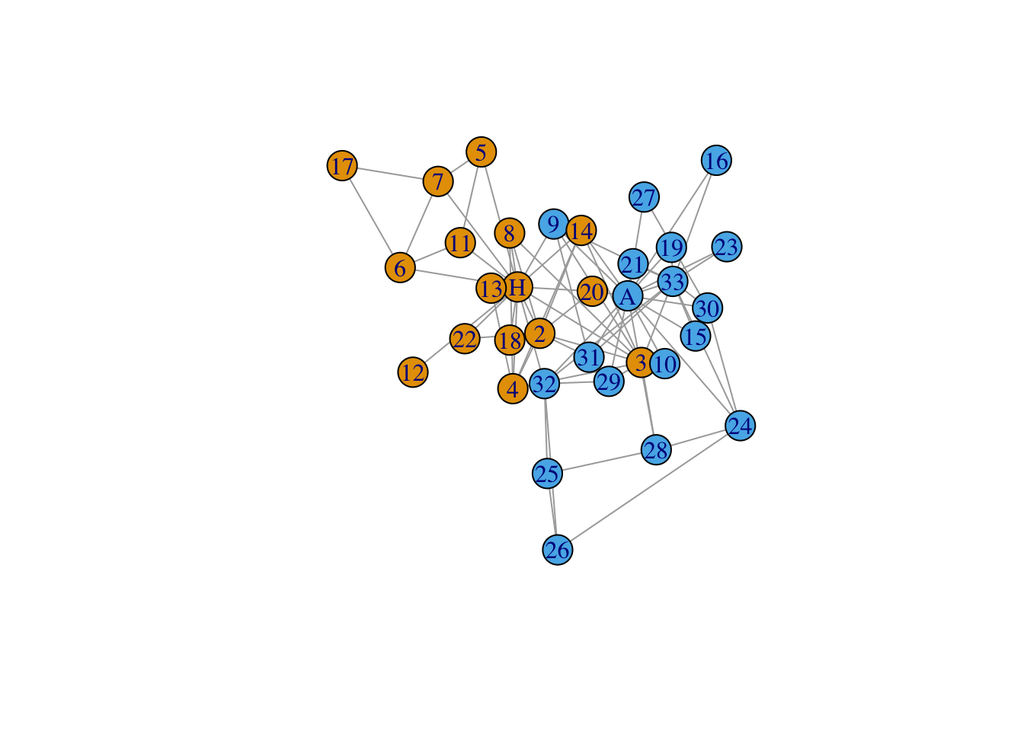

```r
l <- layout.kamada.kawai(karate)
plot(karate, layout=l)
```

- Formes différentes de noeuds :

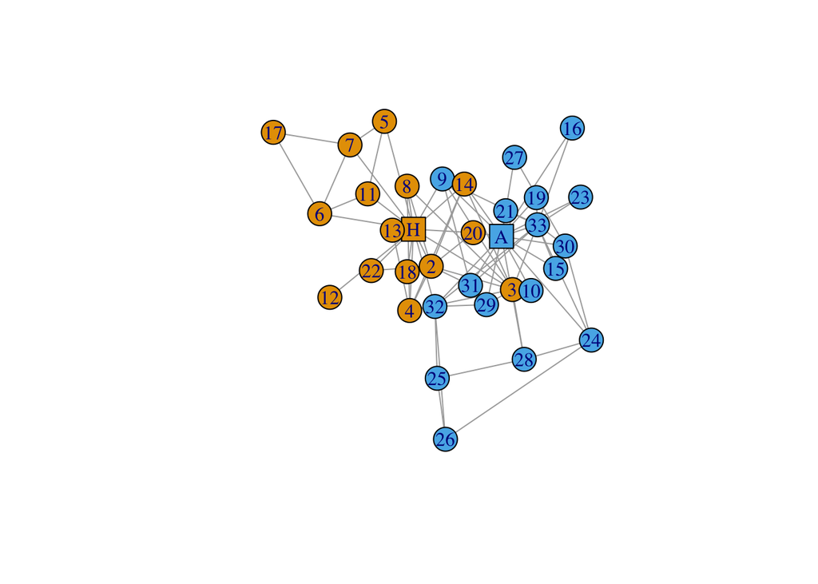

```r
V(karate)$shape <- "circle"
V(karate)[c("Mr Hi", "John A")]$shape <- "rectangle"
plot(karate, layout=l)
```

Ici les noeuds des deux leaders, l’enseignant et l’administrateur sont des rectangles.

- Couleurs différentes de noeuds selon des attributs :

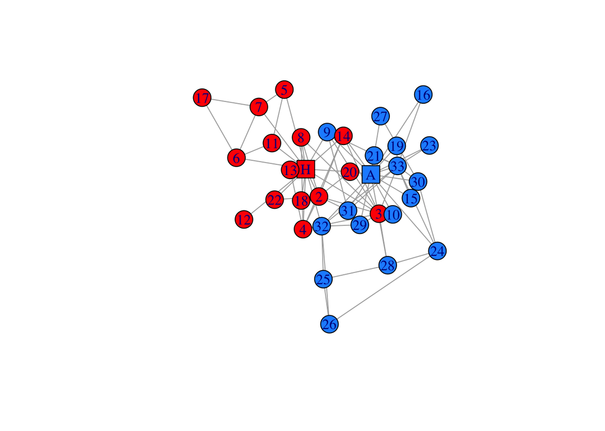

```r
V(karate)[Faction == 1]$color <- "red"
V(karate)[Faction == 2]$color <- "dodgerblue"
plot(karate, layout=l)
```

Le clan de Mr Hi en rouge et celeui de John A en bleu.

- Taille des noeuds proportionnelle à leur force (somme des poids des arêtes incidentes) :

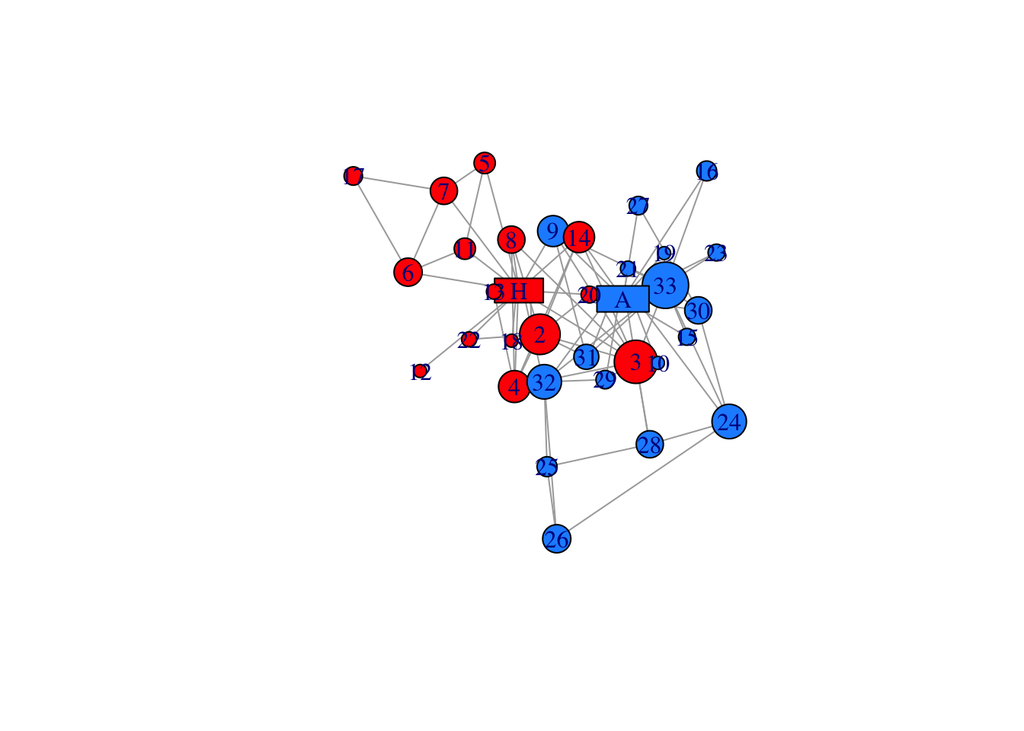

```r
V(karate)$size <- 4*sqrt(graph.strength(karate))
V(karate)$size2 <- V(karate)$size * .5
plot(karate, layout=l)
```

- Epaisseur des arêtes selon des attributs :

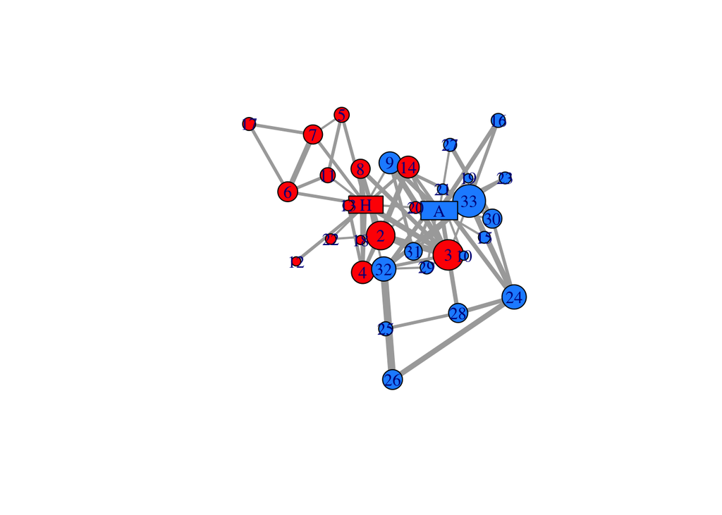

```r
E(karate)$width <- E(karate)$weight
plot(karate, layout=l)
```

Ici, les poids correspondent aux fréquences d’interaction entre les membres.

- Couleur des arêtes selon les attributs :

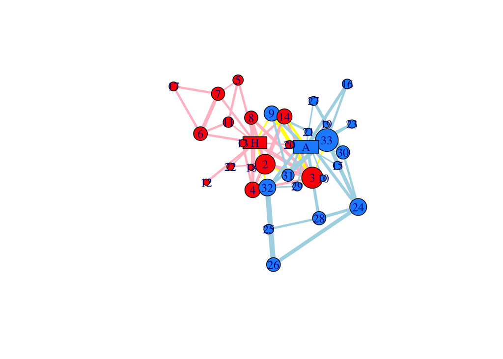

```r
F1 <- V(karate)[Faction==1]
F2 <- V(karate)[Faction==2]
E(karate)[ F1 %--% F1 ]$color <- "pink"
E(karate)[ F2 %--% F2 ]$color <- "lightblue"
E(karate)[ F1 %--% F2 ]$color <- "yellow"
plot(karate, layout=l)
```

Ici selon le fait que les interactions sont inter ou intra clan.

- Décaler le label pour les noeuds très petits :

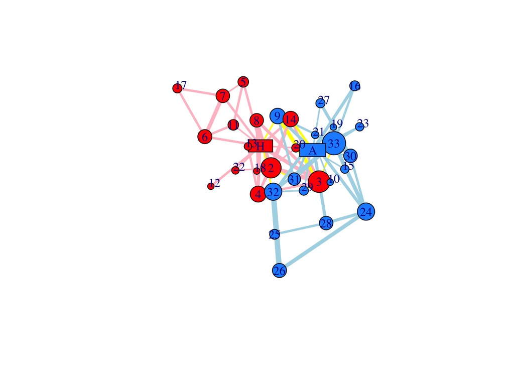

```r
V(karate)$label.dist <-
  ifelse(V(karate)$size >= 10, 0, 0.75)
plot(karate, layout=l)
```

# 3) Graphe bipartite

```r
g.bip <- graph.formula(actor1:actor2:actor3,
                       movie1:movie2, actor1:actor2 - movie1,
                       actor2:actor3 - movie2)
V(g.bip)$type <- grepl("^movie", V(g.bip)$name)
g.bip
```

```
## IGRAPH 3554676 UN-B 5 4 --
## + attr: name (v/c), type (v/l)
## + edges from 3554676 (vertex names):
## [1] actor1--movie1 actor2--movie1 actor2--movie2 actor3--movie2
```

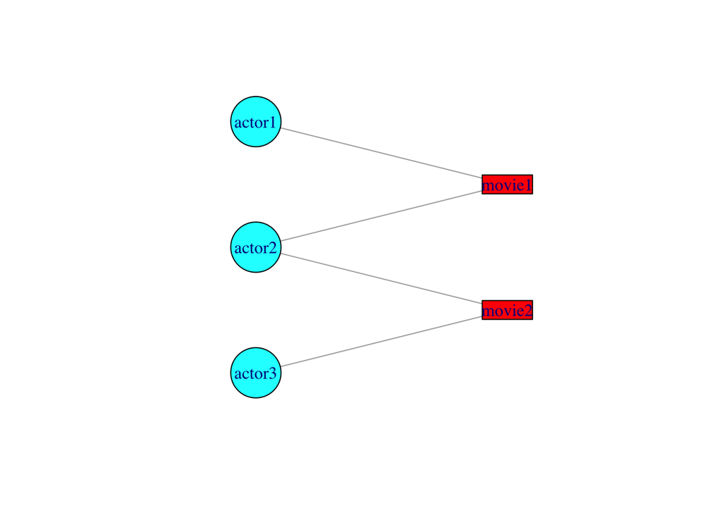

```r
plot(g.bip, layout=-layout.bipartite(g.bip)[,2:1],
     vertex.size=40, vertex.shape=ifelse(V(g.bip)$type,"rectangle", "circle"),
     vertex.color=ifelse(V(g.bip)$type, "red", "cyan"))
```